# nkelley_FinalHomeworkCode_05

Natalia Kelley

# Preliminaries

**Begin by loading relevant packages. May need to install tidyverse, ggplot2, gridExtra, lmodel2, and sciplot.**

```r
library(tidyverse)
library(curl)
library(dplyr)
```

```r
library(ggplot2)
```

```r
library(sciplot)
```

# Part One: Linear Regression and Coefficients

**[1] Using the “KamilarAndCooperData.csv” dataset, run a linear regression looking at log(HomeRange_km2) in relation to log(Body_mass_female_mean) and report your β coeffiecients (slope and intercept).**

```r
f <- curl("https://raw.githubusercontent.com/fuzzyatelin/fuzzyatelin.github.io/master/AN588_Fall21/KamilarAndCooperData.csv")
c <- read.csv(f, header = TRUE, sep = ",", stringsAsFactors = FALSE)
#creates data frame from raw csv file
colnames(c)
```

```
##  [1] "Scientific_Name"         "Family"
##  [3] "Genus"                   "Species"
##  [5] "Brain_Size_Species_Mean" "Brain_Size_Female_Mean"
##  [7] "Brain_size_Ref"          "Body_mass_male_mean"
##  [9] "Body_mass_female_mean"   "Mass_Dimorphism"
## [11] "Mass_Ref"                "MeanGroupSize"
## [13] "AdultMales"              "AdultFemale"
## [15] "AdultSexRatio"           "Social_Organization_Ref"
## [17] "InterbirthInterval_d"    "Gestation"
## [19] "WeaningAge_d"            "MaxLongevity_m"
## [21] "LitterSz"                "Life_History_Ref"
## [23] "GR_MidRangeLat_dd"       "Precip_Mean_mm"
## [25] "Temp_Mean_degC"          "AET_Mean_mm"
## [27] "PET_Mean_mm"             "Climate_Ref"
## [29] "HomeRange_km2"           "HomeRangeRef"
## [31] "DayLength_km"            "DayLengthRef"
## [33] "Territoriality"          "Fruit"
## [35] "Leaves"                  "Fauna"
## [37] "DietRef1"                "Canine_Dimorphism"
## [39] "Canine_Dimorphism_Ref"   "Feed"
## [41] "Move"                    "Rest"
## [43] "Social"                  "Activity_Budget_Ref"
```

```r
#next, I generate a linear regression for log(HomeRange_km2) in relation to log(Body_mass_female_mean) and summarize the results
d <- lm(log(HomeRange_km2) ~ log(Body_mass_female_mean), data = c)
summary(d)
```

```
##
## Call:
## lm(formula = log(HomeRange_km2) ~ log(Body_mass_female_mean),
##     data = c)
##
## Residuals:
##     Min      1Q  Median      3Q     Max
## -3.3929 -0.9433 -0.0126  1.0944  3.6826
##
## Coefficients:
##                            Estimate Std. Error t value Pr(>|t|)
## (Intercept)                -9.44123    0.67293  -14.03   <2e-16 ***
## log(Body_mass_female_mean)  1.03643    0.08488   12.21   <2e-16 ***
## ---
## Signif. codes:  0 '***' 0.001 '**' 0.01 '*' 0.05 '.' 0.1 ' ' 1
##
## Residual standard error: 1.423 on 135 degrees of freedom
##   (76 observations deleted due to missingness)
## Multiple R-squared:  0.5248, Adjusted R-squared:  0.5213
## F-statistic: 149.1 on 1 and 135 DF,  p-value: < 2.2e-16
```

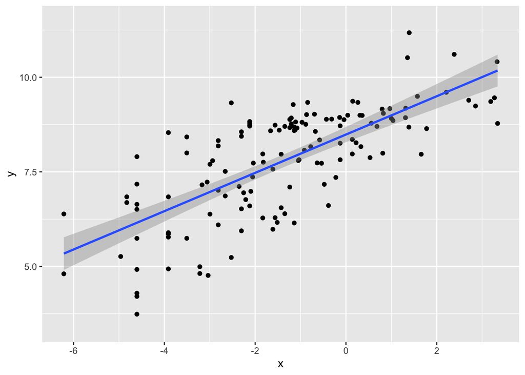

```r
#here we can view the results of the linear regression using ggplot
x <- log(c$HomeRange_km2)
y <- log(c$Body_mass_female_mean)
g <- ggplot(data = c, aes(x = x, y = y))
g <- g + geom_point()
g <- g + geom_smooth(method = "lm", formula = y ~ x)
g
```

```r
t <- coef(summary(d))
t <- data.frame(unlist(t))
colnames(t) <- c("Est", "SE", "t", "p")
t
```

```
##                                  Est         SE         t            p
## (Intercept)                -9.441231 0.67293459 -14.02994 3.820677e-28
## log(Body_mass_female_mean)  1.036432 0.08487709  12.21097 1.447292e-23
```

```r
#beta0 (y-intercept):
lmbeta0 <- t$Est[1]
#beta1 (slope):
lmbeta1 <- t$Est[2]

lm_coeff <- data.frame(lmbeta0, lmbeta1)
lm_coeff
```

```
##     lmbeta0  lmbeta1
## 1 -9.441231 1.036432
```

# Part Two: Bootstrapping Coefficients

**[2] Then, use bootstrapping to sample from your data 1000 times with replacement, each time fitting the same model and calculating the same coefficients. This generates a sampling distribution for each β coefficient.**

```r
#begin by making containers for the coefficients
bsb0 <- NULL
bsb1 <- NULL

#now set up the for loop
for(i in 1:1000) {
  #first, generate 1000 random samples from the data
  sample_c = c[sample(1:nrow(c), nrow(c), replace = TRUE), ]

  #next, run linear regression on the samples
  c_bootstrap <- lm(log(HomeRange_km2) ~ log(Body_mass_female_mean), data = sample_c)

  #extract the coefficients and save in the prepared containers
  bsb0 <- c(bsb0, c_bootstrap$coefficients[1])
  bsb1 <- c(bsb1, c_bootstrap$coefficients[2])
}
```

## Standard Error Estimates

**Estimate the standard error for each of your β coefficients as the standard deviation of the sampling distribution from your bootstrap and determine the 95% CI for each of your β coefficients based on the appropriate quantiles from your sampling distribution.**

```r
#calculate the mean, standard deviation, and standard error of each bootstrapped coefficient (b0, b1)
mean_bsb0 <- mean(bsb0)
mean_bsb1 <- mean(bsb1)
sd_bsb0 <- sd(bsb0)
sd_bsb1 <- sd(bsb1)
se_bsb0 <- se(bsb0)
se_bsb1 <- se(bsb1)

#combine values into a list
bs_mean <- c(mean_bsb0, mean_bsb1)
bs_sd <- c(sd_bsb0, sd_bsb1)
bs_error <- data.frame(se_bsb0, se_bsb1)

#these values will be incorporated into a data frame with CI in the next chunk...
```

```r
#next calculate CI for each bootstrapped coefficient:

#CI for b0
bsb0_upper <- mean(bsb0) + qnorm(0.975, mean = 0, sd = 1) * se(bsb0)
bsb0_lower <- mean(bsb0) + qnorm(0.025, mean = 0, sd = 1) * se(bsb0)
ci_bsb0 <- c(bsb0_lower, bsb0_upper)
ci_bsb0
```

```
## [1] -9.489159 -9.414519
```

```r
#CI for b1
bsb1_upper <- mean(bsb1) + qnorm(0.975, mean = 0, sd = 1) * se(bsb1)
bsb1_lower <- mean(bsb1) + qnorm(0.025, mean = 0, sd = 1) * se(bsb1)
ci_bsb1 <- c(bsb1_lower, bsb1_upper)
ci_bsb1
```

```
## [1] 1.033125 1.042713
```

```r
#this separates by lower and upper CI so they can be incorporated into a larger data frame continuing from the previous chunk
bs_lowerCI <- c(bsb0_lower, bsb1_lower)
bs_upperCI <- c(bsb0_upper, bsb1_upper)

#organize all values into a data frame for readability
bs_df <- data.frame(bs_mean, bs_sd, bs_error, bs_lowerCI, bs_upperCI)
bs_df
```

```
##     bs_mean      bs_sd    se_bsb0     se_bsb1 bs_lowerCI bs_upperCI
## 1 -9.451839 0.60213470 0.01904117 0.002445942  -9.489159  -9.414519
## 2  1.037919 0.07734747 0.01904117 0.002445942   1.033125   1.042713
```

## Comparison of lm() vs. Bootstrap Standard Error

**How does the former compare to the SE estimated from your entire dataset using the formula for standard error implemented in lm()?**

```r
#linear regression error
se_lmb0 <- t$SE[1]
se_lmb1 <- t$SE[2]
lm_error <- data.frame(se_lmb0, se_lmb1)
lm_error
```

```
##     se_lmb0    se_lmb1
## 1 0.6729346 0.08487709
```

```r
#bootstrap error
bs_error
```

```
##      se_bsb0     se_bsb1
## 1 0.01904117 0.002445942
```

The standard error calculated from the linear regression model is much greater than the standard error calculated using the bootstrapping method.

## Comparison of lm() CI versus Bootstrap CI

```r
#linear regression CI
ci_lm <- confint(d, level = 0.90)
ci_lm
```

```
##                                    5 %      95 %
## (Intercept)                -10.5557585 -8.326704
## log(Body_mass_female_mean)   0.8958565  1.177007
```

```r
#boostrap CI
ci_bsb0
```

```
## [1] -9.489159 -9.414519
```

```r
ci_bsb1
```

```
## [1] 1.033125 1.042713
```

The linear regression confidence intervals for b0 and b1 are larger than the bootstrapped confidence intervals, reflecting greater accuracy in the bootstrapped estimates than the linear regression estimates.

# Challenges

1. I finally realized that the reason my code hasn’t been knitting up to this point was mostly due to all the packages I had installing at the beginning. I switched to just library and this solved the problem.
2. At first, my samples in the for loop weren’t generating different b0, b1 values, but this was due to drawing data from the wrong source.
3. After this HW, I better understand how to call individual elements of the linear regression summary.
4. It took me a while to figure out how to format my for loop.
5. At first, when I was setting up my data, I omitted all NA values for the whole data set which omitted a lot of values where the two variables I was looking at actually did have data. When I extracted these and then omitted NA, I was left with much more data to work with. I had noticed the very small (n=26) data set, but I didn’t realize the issue until I saw that Victoria had solved the issue in her own code (thanks to her good annotation).